# Discriminant Analysis

Multivariate Data Analysis

Description for Discriminant Analysis

Yeongeun Jeon  
11-18-2022

- **참고 : R을 활용한 다변량 자료분석 방법론, 강현철 $\cdot$ 연규필 $\cdot$ 한상태 저**

# **1. 재무지표 데이터**

- 판별분석을 수행하기 위해 사용되는 데이터는 [자유아카데미](http://www.freeaca.com/new/library/BoardFileList.aspx?page=1&sword=%eb%8b%a4%eb%b3%80%eb%9f%89&stype=title&area=2)에서 출판한 책 **R을 활용한 다변량 자료분석 방법론**의 데이터 파일 중 “finance.csv”이다.
- 이 데이터는 금융거래의 거래인에 관한 자료로서, 변수들은 다음과 같다.
  1. $x_1$ : 총부채 대비 현금 유출입
  2. $x_2$ : 총자산 대비 순이익
  3. $x_3$ : 채무 대비 자산
  4. $x_4$ : 순매출 대비 자산
  5. $y$ : “1 = 파산 기업”, “2 = 건전 기업”
- 위와 같은 재무지표 데이터를 이용하여 거래인의 신용등급을 판별하고자 한다.

```
# 데이터 불러오기
finance <- read.csv("C:/Users/User/Desktop/finance.csv")
head(finance)
```

```
  ID     x1     x2    x3    x4 y
1  1 -0.448 -0.410 1.086 0.452 1
2  2 -0.563 -0.311 1.513 0.164 1
3  3  0.064  0.015 1.007 0.397 1
4  4 -0.072 -0.093 1.454 0.258 1
5  5 -0.100 -0.091 1.564 0.668 1
6  6 -0.142 -0.065 0.706 0.279 1
```

```
# 데이터 전처리pacman::p_load("dplyr")

finance.X <- finance %>%
  select(2:5)                                      # 판별변수 선택

head(finance.X)
```

```
      x1     x2    x3    x4
1 -0.448 -0.410 1.086 0.452
2 -0.563 -0.311 1.513 0.164
3  0.064  0.015 1.007 0.397
4 -0.072 -0.093 1.454 0.258
5 -0.100 -0.091 1.564 0.668
6 -0.142 -0.065 0.706 0.279
```

※ 비록 예제에서는 적용하지 않겠지만, 데이터의 전처리는 판별분석의 응용에서 중요하다. 판별분석의 적용에 앞서 수치형 변수는 중심화와 척도화, 즉, 함수 `scale(, center = TRUE, scale = TRUE)`를 이용하여 정규화를 수행하여야 한다.

# **2. 다변량 정규분포에 기초한 판별분석**

- 부분모집단들이 $p$차원 다변량 정규분포를 따르는 경우, 판별분석은 `부분집단별 모공분산행렬의 동일성 여부`에 따라 선형 판별분석과 이차 판별분석으로 구분되어 질 수 있다.
  - 만약 총 $G$개의 부분집단의 모공분산행렬이 동일하다면, 즉, $\boldsymbol{\Sigma}_1=\ldots=\boldsymbol{\Sigma}_G=\boldsymbol{\Sigma}$, 선형 판별분석을 수행한다.
  - 만약 총 $G$개의 부분집단의 모공분산행렬이 동일하지 않다면, 이차 판별분석을 수행한다.
- $G$개의 부분집단의 모공분산행렬 동일성 검정은 Package `biotools`에서 제공하는 함수 `boxM()`을 통해 수행할 수 있다.

```
# 모공분산행렬의 동일성에 대한 검정pacman::p_load("biotools")

finance.boxM <- boxM(finance.X,                   # 데이터행렬NAfinance$y)                   # 집단변수
finance.boxM
```

```
    Box's M-test for Homogeneity of Covariance Matrices

data:  finance.X
Chi-Sq (approx.) = 64.869, df = 10, p-value = 4.294e-10
```

`Result!` 가설 $H_0 : \boldsymbol{\Sigma}_1=\boldsymbol{\Sigma}_2$, $H_1 : \boldsymbol{\Sigma}_1\ne\boldsymbol{\Sigma}_2$에 대하여, 카이제곱 검정통계량 $\chi^2$ 값은 64.869, $p$-값은 0에 가깝다. 이에 근거하여, 유의수준 5%에서 $p$-값이 0.05보다 작기 때문에 귀무가설 $H_0$를 기각할 수 있다. 즉, 두 부분집단의 모공분산행렬은 동일하지 않다.

※ 하지만, 판별분석에 대해 전반적으로 설명하기 위해 모공분산행렬의 동일성 가정을 만족하지 않아도 재무지표 데이터를 이용한다.

## **2-1. 선형 판별분석**

- 모공분산행렬에 대한 동일성, 즉, $\boldsymbol{\Sigma}_1=\ldots=\boldsymbol{\Sigma}_G=\boldsymbol{\Sigma}$을 가정하는 경우 공통 공분산행렬 $\boldsymbol{\Sigma}$을 합동 표본공분산행렬(Pooled Sample Covariance Matirx) $\boldsymbol{S}=\sum_{g=1}^G \frac{(n_g-1)\boldsymbol{S}_g}{n-g}$로 대치할 수 있다.
  - $n$ : 전체 개체 수
  - $n_g$ : 집단 $g$의 개체 수
  - $\boldsymbol{S}_g$ : 집단 $g$의 표본공분산행렬
- 모평균벡터도 표본평균벡터 $\bar{\boldsymbol{X}}_g$로 대치하면 다변량 정규밀도함수로부터 다음과 같은 선형 판별함수를 얻을 수 있다.
  $$\begin{align}
  L_g(\boldsymbol{X})=-\frac{1}{2}\bar{\boldsymbol{X}}^T_g\boldsymbol{S}^{-1}\bar{\boldsymbol{X}}_g
  + \bar{\boldsymbol{X}}^T_g\boldsymbol{S}^{-1}\boldsymbol{X}
  \end{align}$$
  - 여기서 $L_g(\boldsymbol{X})$은 집단 $g$에 속할 확률인 $P(y=g|\boldsymbol{X})$을 의미한다.

```
# 집단 분류x1 <- as.matrix(finance.X[which(finance$y==1),])   # y = 1인 집단 NAx2 <- as.matrix(finance.X[which(finance$y==2),])   # y = 2인 집단NAn1 <- nrow(x1)                                     # y = 1인 집단의 개체 개수n2 <- nrow(x2)                                     # y = 2인 집단의 개체 개수
# 평균벡터 계산xbar1 <- apply(x1, 2, mean)
print(xbar1,digits=4)
```

```
      x1       x2       x3       x4
-0.07319 -0.08181  1.36705  0.43786
```

```
xbar2 <- apply(x2, 2, mean)
print(xbar2,digits=4)
```

```
     x1      x2      x3      x4
0.23492 0.05472 2.58040 0.42812
```

```
# 합동 표본공분산 행렬
pacman::p_load("Morpho")

# 집단에 대한 합동 표본공분산행렬S <- covW(finance.X,                               # 데이터행렬NAas.factor(finance$y))                    # 집단변수
S
```

```
             x1          x2         x3           x4
x1  0.044975115 0.017034959 0.05723586 -0.001399235
x2  0.017034959 0.010721643 0.01647615  0.001627191
x3  0.057235863 0.016476150 0.64941902  0.029682931
x4 -0.001399235 0.001627191 0.02968293  0.034807846
attr(,"means")
           x1          x2       x3        x4
1 -0.07319048 -0.08180952 1.367048 0.4378571
2  0.23492000  0.05472000 2.580400 0.4281200
```

`Caution!` Package `Morpho`에서 제공하는 함수 `covW()`를 통해 합동 표본공분산행렬을 얻을 수 있다.

```
# 선형 판별계수
L1.a <- -(1/2)*t(xbar1)%*%solve(S)%*%xbar1
print(L1.a,digits=4)
```

```
       [,1]
[1,] -4.384
```

```
L1.b <- solve(S)%*%xbar1
print(L1.b,digits=4)
```

```
      [,1]
x1   2.844
x2 -16.625
x3   1.728
x4  11.997
```

```
L2.a <- -(1/2)*t(xbar2)%*%solve(S)%*%xbar2
print(L2.a,digits=4)
```

```
       [,1]
[1,] -6.756
```

```
L2.b <- solve(S)%*%xbar2
print(L2.b,digits=4)
```

```
     [,1]
x1  4.739
x2 -9.065
x3  3.325
x4 10.078
```

`Result!` 유도된 선형 판별함수는 다음과 같으며, 각 선형 판별함수들은 집단 1, 2에 속할 확률이다.
$$\begin{align}
L_1(\boldsymbol{x})&=-4.384+2.844x_1-16.625x_2+1.728x_3+11.997x_4,\\
L_2(\boldsymbol{x})&=-6.756+4.739x_1-9.065x_2+3.325x_3+10.078x_4.
\end{align}$$
또한, 두 집단 선형 판별함수의 차이를 계산하면 다음과 같다.
$$\begin{align}
L(\boldsymbol{x})=L_2(\boldsymbol{x})-L_1(\boldsymbol{x})=-2.372+1.895x_1+7.560x_2+1.597x_3-1.919x_4.
\end{align}$$
선형 판별계수들의 부호에 관심을 가지고 이를 해석해보면, $x_1$(총부채 대비 현금 유출입), $x_2$(총자산 대비 순이익), $x_3$(채무 대비 자산)이 클수록 $L(\boldsymbol{x})$ 값이 커지므로 파산 기업($y=1$)에 비해 건전 기업($y=2$)에 속할 확률의 추정치가 커지며, 반면에 $x_4$(순매출 대비 자산)이 클수록 $L(\boldsymbol{x})$ 값이 작아지므로 건전 기업($y=2$)에 속할 확률의 추정치가 작아짐을 알 수 있다.

`Caution!` Package `MASS`에서 제공하는 함수 `lda()`를 통해 `두 집단 선형 판별함수의 차이` $L(\boldsymbol{x})$를 쉽게 얻을 수 있다. 다만, 함수 `lda()`에서는 각 변수들을 중심화(평균을 0으로 만듦)한 후 분석을 수행하며, 판별계수벡터를 정규화한다. 함수 `lda()`에 대한 자세한 옵션은 [여기](https://www.rdocumentation.org/packages/MASS/versions/7.3-58.1/topics/lda)를 참고한다.

```
# 함수 ldapacman::p_load("MASS")

finance.lda <- lda(y ~ x1 + x2 + x3 + x4,           # formula : 반응변수(집단변수) ~ 판별변수수
                   # prior = c(1/2, 1/2),           # 사전확률                   data = finance)
finance.lda
```

```
Call:
lda(y ~ x1 + x2 + x3 + x4, data = finance)

Prior probabilities of groups:
        1         2
0.4565217 0.5434783

Group means:
           x1          x2       x3        x4
1 -0.07319048 -0.08180952 1.367048 0.4378571
2  0.23492000  0.05472000 2.580400 0.4281200

Coefficients of linear discriminants:
          LD1
x1  1.0023665
x2  3.9998578
x3  0.8450508
x4 -1.0153181
```

`Result!` “Prior probabilities of groups”는 사전확률을 의미하며, 함수 `lda()`의 옵션 `prior`을 이용하여 직접 지정할 수 있다. 만약 옵션으로 따로 지정해주지 않는다면, 예제처럼 데이터에서 계산된 각 집단의 비율이 사전확률로 지정된다. 즉, 데이터 “finance”에서 파산 기업($y=1$)의 비율은 46%, 건전 기업($y=2$)의 비율은 54%이다. “Groups means”는 판별변수들의 집단별 평균을 의미한다. 예를 들어, 변수 $x_4$(순매출 대비 자산)은 두 집단의 평균이 0.438과 0.428로서 큰 차이가 없으므로, 이 변수는 판별에 기여하는 정도가 작을 것임을 짐작할 수 있다. “Coefficients of linear discriminants”는 선형 판별계수로 이 계수들을 이용하여 선형 판별함수를 표현하면 다음과 같다.
$$\begin{align}
L(\boldsymbol{x})=1.002(x_1-\bar{x}_1)+3.999(x_2-\bar{x}_2)+0.845(x_3-\bar{x}_3)-1.015(x_4-\bar{x}_4).
\end{align}$$
여기서, $\bar{x}_i$는 $i$번째 판별변수의 평균을 의미한다.
선형 판별계수들의 부호에 관심을 가지고 이를 해석해보면, $x_1$(총부채 대비 현금 유출입), $x_2$(총자산 대비 순이익), $x_3$(채무 대비 자산)이 클수록 $L(\boldsymbol{x})$ 값이 커지므로 파산 기업($y=1$)에 비해 건전 기업($y=2$)에 속할 확률의 추정치가 커지며, 반면에 $x_4$(순매출 대비 자산)이 클수록 $L(\boldsymbol{x})$ 값이 작아지므로 건전 기업($y=2$)에 속할 확률의 추정치가 작아진다.

```
# 새로운 개체에 대한 집단 예측
pred.finance <- predict(finance.lda,                # 함수 lda로부터 출력된 객체NAfinance)                    # 새로운 데이터pred.finance
```

```
$class
 [1] 1 1 1 1 1 1 1 1 1 1 1 1 1 1 2 2 1 1 1 2 1 2 2 2 2 2 2 2 2 2 2 2 2
[34] 1 2 2 2 2 2 2 2 2 2 2 2 2
Levels: 1 2

$posterior
              1           2
1  0.9949306255 0.005069374
2  0.9710865699 0.028913430
3  0.7534057857 0.246594214
4  0.7703536176 0.229646382
5  0.8652242888 0.134775711
6  0.9142224102 0.085777590
7  0.7275761568 0.272423843
8  0.7900065070 0.209993493
```

[output cut: 87 more lines]

`Caution!` 함수 `predict()`를 이용하면 유도된 선형 판별함수로부터 새로운 개체에 대한 집단 예측을 수행할 수 있다.  
`Result!` 함수 `predict()`는 3개의 객체를 생성한다.

1. `x` : 새로운 개체에 대한 선형 판별점수 $L(\boldsymbol{x})$ 값이 저장되어 있다.
2. `posterior` : 예측된 소속 확률 $P(y=g|\boldsymbol{x})$이 저장되어 있다.
3. `class` : 예측된 소속 집단이 저장되어 있다.
   - 위의 예제에서는 다음과 같이 집단을 예측한다.
     - $P(y=1|\boldsymbol{x})>P(y=2|\boldsymbol{x})$, 즉, $L(\boldsymbol{x})<0$이면, 집단 1(파산 기업)에 분류
     - $P(y=1|\boldsymbol{x})<P(y=2|\boldsymbol{x})$, 즉, $L(\boldsymbol{x})>0$이면, 집단 2(건전 기업)에 분류

```
# 선형 판별점수, 예측 확률, 예측 집단pf <- cbind(finance, pred.finance$x, pred.finance$posterior, pred.finance$class)
pf
```

```
   ID     x1     x2    x3    x4 y          LD1            1
1   1 -0.448 -0.410 1.086 0.452 1 -2.967536513 0.9949306255
2   2 -0.563 -0.311 1.513 0.164 1 -2.033574427 0.9710865699
3   3  0.064  0.015 1.007 0.397 1 -0.765301792 0.7534057857
4   4 -0.072 -0.093 1.454 0.258 1 -0.814741367 0.7703536176
5   5 -0.100 -0.091 1.564 0.668 1 -1.158132769 0.8652242888
6   6 -0.142 -0.065 0.706 0.279 1 -1.426330659 0.9142224102
7   7  0.035  0.014 1.504 0.708 1 -0.694143990 0.7275761568
8   8 -0.065 -0.056 1.373 0.403 1 -0.875400305 0.7900065070
9   9 -0.072 -0.007 1.372 0.336 1 -0.619242570 0.6986301491
10 10 -0.135 -0.143 1.419 0.434 1 -1.286156120 0.8910355393
11 11 -0.229 -0.296 0.331 0.182 1 -2.655911886 0.9909008401
12 12  0.073  0.020 1.312 0.249 1 -0.328273634 0.5721926558
13 13  0.010  0.001 2.149 0.696 1 -0.213959740 0.5186738620
14 14 -0.227 -0.231 1.191 0.660 1 -2.152494806 0.9767718689
```

[output cut: 79 more lines]

```
# 오분류표
pacman::p_load("DescTools")

# 도수분포표
finance.ctbl1 <- table(finance$y,                   # 실제 집단                       pred.finance$class)          # 예측된 집단finance.ctbl1
```

```
     1  2
  1 18  3
  2  1 24
```

```
Desc(finance.ctbl1,                                 # 도수분포표
     digits = 4)
```

```
--------------------------------------------------------------------
finance.ctbl1 (table)

Summary:
n: 5e+01, rows: 2e+00, columns: 2e+00

Pearson's Chi-squared test (cont. adj):
  X-squared = 28.154, df = 1, p-value = 1.121e-07
Fisher's exact test p-value = 8.054e-09
McNemar's chi-squared = 0.25, df = 1, p-value = 0.6171

                    estimate   lwr.ci   upr.ci'

odds ratio           144.000   13.813 1501.237
rel. risk (col1)      21.429    3.116  147.380
rel. risk (col2)       0.149    0.052    0.426


Phi-Coefficient        0.827
Contingency Coeff.     0.637
Cramer's V             0.827


                    1         2       Sum

1     freq      2e+01     3e+00     2e+01
      perc   39.1304%   6.5217%  45.6522%
      p.row  85.7143%  14.2857%         .
      p.col  94.7368%  11.1111%         .

2     freq      1e+00     2e+01     2e+01
      perc    2.1739%  52.1739%  54.3478%
      p.row   4.0000%  96.0000%         .
      p.col   5.2632%  88.8889%         .

Sum   freq      2e+01     3e+01     5e+01
      perc   41.3043%  58.6957% 100.0000%
      p.row         .         .         .
      p.col         .         .         .


----------
' 95% conf. level
```

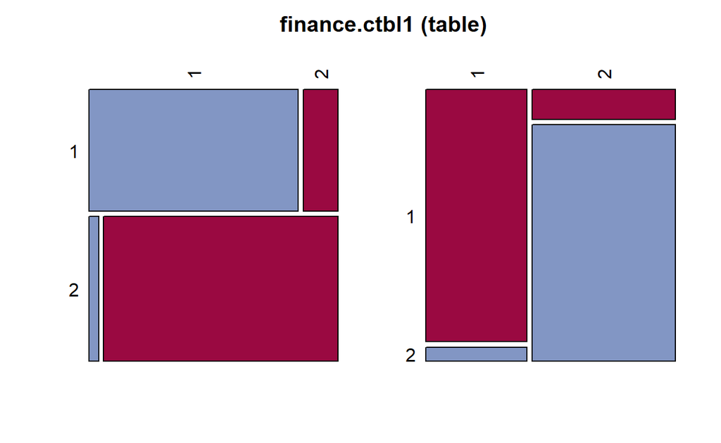

`Caution!` Package `DescTools`에서 제공하는 함수 `Desc()`를 이용하여 오분류표를 작성할 수 있다.  
`Result!` 원래 집단 1에 속하는 21개의 개체 중 18개(18/21=85.7%)는 집단 1에 제대로 분류되었으나 3개(3/21=14.3%)는 집단 2로 잘못 분류되었다. 또한, 원래 집단 2에 속하는 25개의 개체 중 1개(1/25=4%)는 집단 1로 잘못 분류되었으나 24개(24/25=96%)는 집단 2에 제대로 분류되었다. 유도된 선형 판별함수에 대한 오류율은 (3+1)/46=8.7%이며, 정확도는 (18+24)/46=91.3%이다.

## **2-2. 이차 판별분석**

- 선형 판별함수는 부분모집단의 공분산행렬이 같다는 가정 하에 유도된 것이므로, 이러한 가정이 적절하지 않은 데이터에 대해서는 상당히 왜곡된 결과를 도출할 수 있다.
- 부분모집단의 공분산행렬이 다른 경우, 비선형 판별함수인 이차 판별함수를 통해 판별분석을 수행한다.
- 다변량 정규분포를 가정한다면, 집단 $g$에 속할 확률 $P(y=g|\boldsymbol{X})$는 다변량 정규밀도함수에 비례하며, 다변량 정규밀도 함수는 다음과 같은 이차함수로 나타낼 수 있다.
  $$\begin{align}
  Q_g(\boldsymbol{X})=(\boldsymbol{X}-\bar{\boldsymbol{X}}_g)^T\boldsymbol{S}^{-1}_g(\boldsymbol{X}-\bar{\boldsymbol{X}}_g).
  \end{align}$$
  - 즉, $P(y=g|\boldsymbol{X})\propto Q_g(\boldsymbol{X})$
- 이차 판별분석은 Package `MASS`에서 제공하는 함수 `qda()`를 통해 수행할 수 있으며, 자세한 옵션은 [여기](https://www.rdocumentation.org/packages/MASS/versions/7.3-58.1/topics/qda)를 참고한다.

```
# 이차 판별분석pacman::p_load("MASS")

finance.qda <- qda(y ~ x1 + x2 + x3 + x4,           # formula : 반응변수(집단변수) ~ 판별변수수
                   data = finance)
finance.qda
```

```
Call:
qda(y ~ x1 + x2 + x3 + x4, data = finance)

Prior probabilities of groups:
        1         2
0.4565217 0.5434783

Group means:
           x1          x2       x3        x4
1 -0.07319048 -0.08180952 1.367048 0.4378571
2  0.23492000  0.05472000 2.580400 0.4281200
```

`Caution!` 이차 판별분석에서는 판별계수벡터를 출력하지 않는다.

```
# 새로운 개체에 대한 집단 예측
pred2.finance <- predict(finance.qda,               # 함수 qda로부터 출력된 객체NAfinance)                   # 새로운 데이터cbind(finance, pred2.finance$posterior, pred2.finance$class)
```

```
   ID     x1     x2    x3    x4 y            1            2
1   1 -0.448 -0.410 1.086 0.452 1 1.000000e+00 3.116818e-39
2   2 -0.563 -0.311 1.513 0.164 1 1.000000e+00 1.111932e-14
3   3  0.064  0.015 1.007 0.397 1 5.421135e-01 4.578865e-01
4   4 -0.072 -0.093 1.454 0.258 1 9.983000e-01 1.699964e-03
5   5 -0.100 -0.091 1.564 0.668 1 9.999242e-01 7.579056e-05
6   6 -0.142 -0.065 0.706 0.279 1 8.842837e-01 1.157163e-01
7   7  0.035  0.014 1.504 0.708 1 8.582123e-01 1.417877e-01
8   8 -0.065 -0.056 1.373 0.403 1 9.739957e-01 2.600431e-02
9   9 -0.072 -0.007 1.372 0.336 1 5.907891e-01 4.092109e-01
10 10 -0.135 -0.143 1.419 0.434 1 9.999995e-01 4.807386e-07
11 11 -0.229 -0.296 0.331 0.182 1 1.000000e+00 3.046234e-22
12 12  0.073  0.020 1.312 0.249 1 6.209643e-01 3.790357e-01
13 13  0.010  0.001 2.149 0.696 1 5.581252e-01 4.418748e-01
14 14 -0.227 -0.231 1.191 0.660 1 1.000000e+00 3.388701e-17
```

[output cut: 79 more lines]

`Caution!` 이차 판별분석에서 함수 `predict()`는 판별점수를 출력하지 않는다.

```
# 오분류표
pacman::p_load("DescTools")

# 도수분포표
finance.ctbl2 <- table(finance$y,                   # 실제 집단                       pred2.finance$class)         # 예측된 집단finance.ctbl2
```

```
     1  2
  1 19  2
  2  1 24
```

```
Desc(finance.ctbl2,                                 # 도수분포표
     digits = 4)
```

```
--------------------------------------------------------------------
finance.ctbl2 (table)

Summary:
n: 5e+01, rows: 2e+00, columns: 2e+00

Pearson's Chi-squared test (cont. adj):
  X-squared = 31.3, df = 1, p-value = 2.21e-08
Fisher's exact test p-value = 9.399e-10
McNemar's chi-squared = 0, df = 1, p-value = 1

                    estimate   lwr.ci   upr.ci'

odds ratio          2.28e+02 1.92e+01 2.71e+03
rel. risk (col1)    2.26e+01 3.30e+00 1.55e+02
rel. risk (col2)    9.92e-02 2.65e-02 3.72e-01


Phi-Coefficient        0.869
Contingency Coeff.     0.656
Cramer's V             0.869


                    1         2       Sum

1     freq      2e+01     2e+00     2e+01
      perc   41.3043%   4.3478%  45.6522%
      p.row  90.4762%   9.5238%         .
      p.col  95.0000%   7.6923%         .

2     freq      1e+00     2e+01     2e+01
      perc    2.1739%  52.1739%  54.3478%
      p.row   4.0000%  96.0000%         .
      p.col   5.0000%  92.3077%         .

Sum   freq      2e+01     3e+01     5e+01
      perc   43.4783%  56.5217% 100.0000%
      p.row         .         .         .
      p.col         .         .         .


----------
' 95% conf. level
```

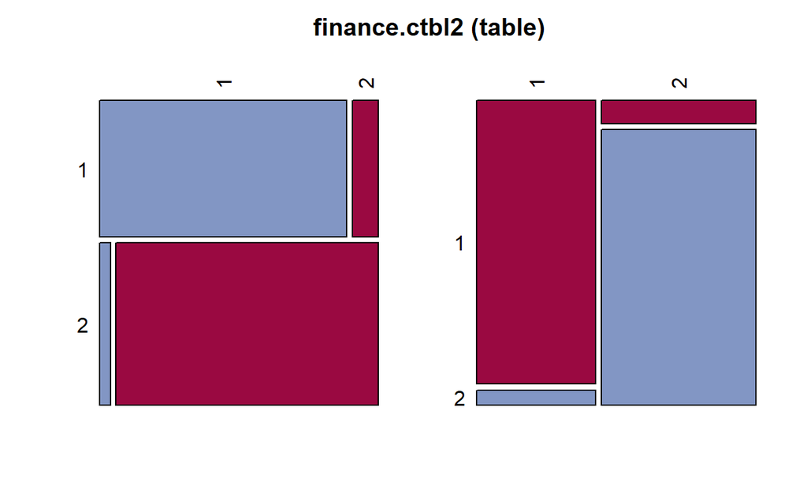

`Caution!` Package `klaR`에서 제공하는 함수 `partimat()`을 통해 판별분석의 분류 영역을 각 판별변수의 쌍에 대하여 표현할 수 있다.

```
# 그래프적 표현NApacman::p_load("klaR")

finance$y <- as.factor(finance$y)

# 선형 판별함수partimat(y ~ x1 + x2 + x3 + x4,
         data = finance,
         method = "lda")
```

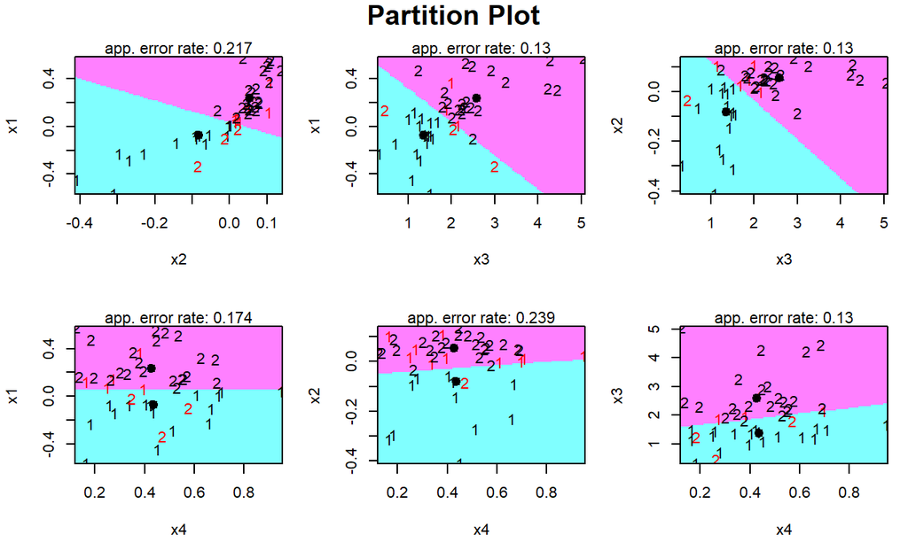

```
# 이차 판별함수NApartimat(y ~ x1 + x2 + x3 + x4,
         data = finance,
         method = "qda")
```

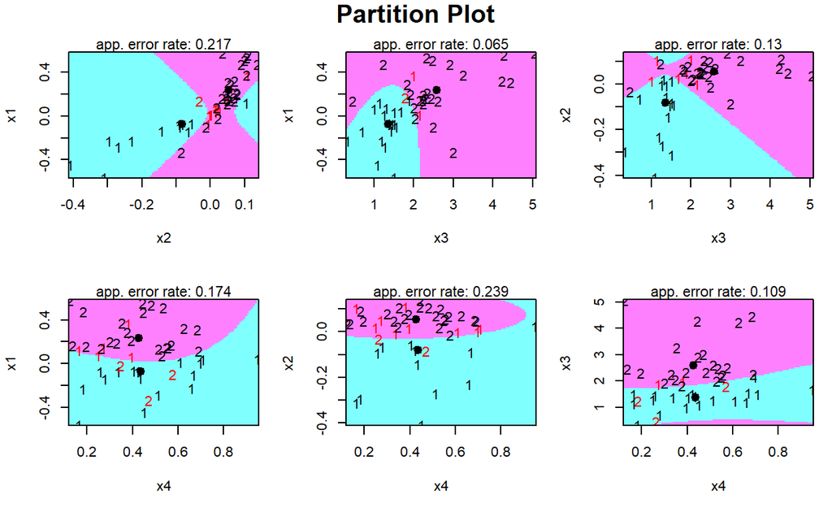

`Result!` 그래프를 통해 선형 판별함수와 이차 판별함수의 “선형”, “이차”라는 용어의 의미를 이해할 수 있다. 선형 판별함수는 각 판별변수의 쌍에 대하여 집단 1과 2는 선형(직선)으로 분류되었으며, 이차 판별함수는 집단 1과 2는 비선형으로 분류되었다. 또한, 각 집단에 대해 잘못 분류된 개체는 빨간색으로 표시되어 있다.

# **3. 정준 판별분석**

- 판별분석은 $G$개의 집단을 가능한 잘 구별할 수 있는 변수들 $X_1, \ldots, X_p$의 함수를 결정하는 것이 중요하다.
- 이런 목적에서 가장 간단한 방법은 판별변수 $\boldsymbol{X}=(X_1, \ldots, X_p)^T$의 선형결합 $V=\boldsymbol{b}^T\boldsymbol{X}=b_1X_1+\ldots+b_pX_p$ 형태를 취하는 것이다.
- 만약 집단내에서 변수 $V$의 값들이 어느 정도 일정하면서 집단간에 $V$의 평균값이 많이 다르면(=집단간 변동이 큼), 집단들은 $V$ 값을 이용해 잘 구별할 수 있다.
- 판별계수 $\boldsymbol{b}^T$를 결정하는 한 가지 방법은 Fisher에 의해서 제안된 방법으로, 분산분석에서 $F=\frac{\text{집단간 변동}}{\text{집단내 변동}}$ 값이 최대가 되도록하는 값들을 선택하는 것이다.
  - 이때 구해진 판별계수 $\boldsymbol{b}^T$를 `정준 판별계수`라고 하며, $V=\boldsymbol{b}^T\boldsymbol{X}=b_1X_1+\ldots+b_pX_p$를 `정준 판별함수`라고 한다.
  - 이 방법을 사용할 때, 집단을 구별하는 여러 개의 선형결합을 찾는 것이 가능한 것으로 밝혀졌다.
    - 일반적으로 $s=\text{min}(G-1, p)$개의 선형결합식을 찾을 수 있다.
- R에서 정준 판별분석을 수행하기 위해서는 Package `MASS`에서 제공하는 함수 `lda()`를 이용하면 된다.

## **3-1. 부분집단이 두 개인 경우**

- 가정 : `모공분산행렬의 동일성`
- 부분집단이 두 개인 경우(즉, $G=2$), Fisher가 제안한 방법은 선형결합식 $V=\boldsymbol{b}^T\boldsymbol{X}=b_1X_1+\ldots+b_pX_p$에 의해 두 개의 집단을 분리하려는 것이다.
- 이때 변환된 두 부분집단의 $V$의 모평균에 대한 이표본 $t$-검정통계량은 다음과 같이 주어진다.
  $$\begin{align*}
  t=\frac{\boldsymbol{b}^T(\bar{\boldsymbol{X}}_1-\bar{\boldsymbol{X}}_2)}{\sqrt{\boldsymbol{b}^T\boldsymbol{S}\boldsymbol{b}(1/n_1+1/n_2)}}
  \end{align*}$$
  - $\bar{\boldsymbol{X}}_1, \bar{\boldsymbol{X}}_2$ : 두 부분집단의 표본평균벡터
  - $\boldsymbol{S}$ : 합동 표본공분산행렬
    - $\boldsymbol{S}=\frac{(n_1-1)\boldsymbol{S}_1+(n_2-1)\boldsymbol{S}_2}{n_1+n_2-2}$
  - $n_1, n_2$ : 두 부분집단의 개체 수
- Fisher의 판별함수는 변환된 $V$에 대해 두 부분집단의 표본평균간의 표준화된 거리의 제곱이 되는 $t^2$을 최대화하는 선형변환이다.
  - 판별분석은 집단간의 거리를 최대화하는 변수들의 선형결합식을 찾는 것이며, 변환된 두 부분집단의 $V$의 모평균의 차이가 클수록(=$t^2$이 클수록) 두 집단간의 거리가 커지는 것을 의미하기 때문이다.
- $t^2$이 최대일 때 판별계수 $\boldsymbol{b}$는 $c\boldsymbol{S}^{-1}(\bar{\boldsymbol{x}}_1-\bar{\boldsymbol{x}}_2)$이 된다.
  - $c$는 $\boldsymbol{b}^T\boldsymbol{S}\boldsymbol{b}=1$이 되도록 만드는 척도화 상수이다.

```
# 정준 판별분석
pacman::p_load("MASS")

finance.lda <- lda(y ~ x1 + x2 + x3 + x4,           # formula : 반응변수(집단변수) ~ 판별변수수
                   data = finance)
finance.lda
```

```
Call:
lda(y ~ x1 + x2 + x3 + x4, data = finance)

Prior probabilities of groups:
        1         2
0.4565217 0.5434783

Group means:
           x1          x2       x3        x4
1 -0.07319048 -0.08180952 1.367048 0.4378571
2  0.23492000  0.05472000 2.580400 0.4281200

Coefficients of linear discriminants:
          LD1
x1  1.0023665
x2  3.9998578
x3  0.8450508
x4 -1.0153181
```

`Result!` 부분집단이 두 개인 경우, 구해진 정준 판별계수는 (1.002, 3.999, 0.845, -1.015)이며, 정준 판별계수를 이용하여 정준 판별함수를 표현하면 다음과 같다.
$$\begin{align*}
V=1.002(x_1-\bar{x}_1)+3.999(x_2-\bar{x}_2)+0.845(x_3-\bar{x}_3)-1.015(x_4-\bar{x}_4).
\end{align*}$$
판별점수($V$)가 클수록, 즉, $x_1$(총부채 대비 현금 유출입), $x_2$(총자산 대비 순이익), $x_3$(채무 대비 자산)이 클수록 건전 기업($y=2$)에 속할 확률이 커지고, 판별점수($V$)가 작을수록, 즉, $x_4$(순매출 대비 자산)이 클수록 건전 기업($y=2$)에 속할 확률이 작아짐을 알 수 있다.

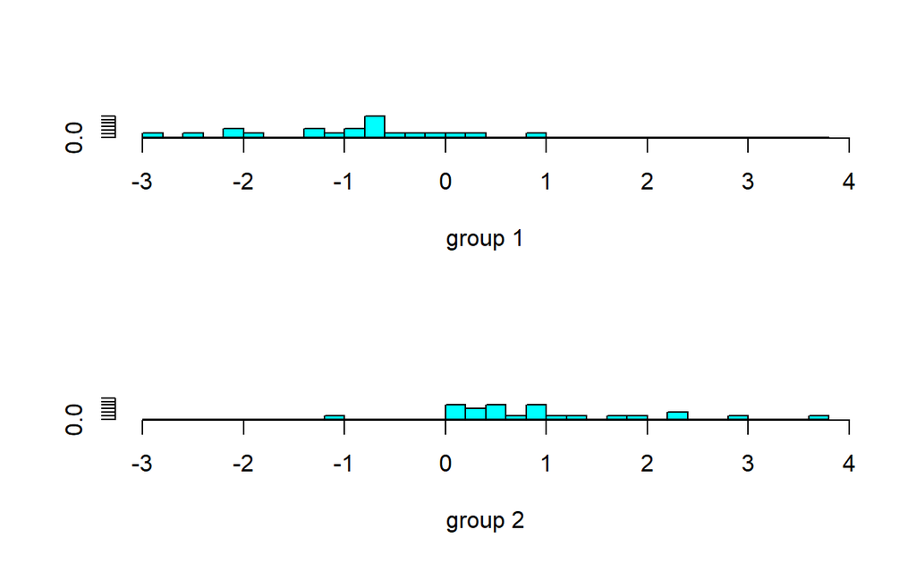

```
# 그래프적 표현NAplot(finance.lda)
```

`Result!` 유도된 판별함수에 의해 계산된 판별점수의 분포를 그래프로 표현한 결과이다. 첫 번째 그래프는 파산 기업($y=1$)에 대한 판별점수의 분포이며, 두 번째 그래프는 건전 기업($y=2$)에 대한 판별점수의 분포이다. 파산 기업($y=1$)에 대한 판별점수, 즉, $V$값은 음수가 나와야 파산 기업($y=1$)으로 분류하며, 이는 0보다 큰 점수에 대해 오분류되었다는 것을 의미한다. 건전 기업($y=2$)에 대한 판별점수, 즉, $V$값은 양수가 나와야 건전 기($y=2$)업으로 분류하며, 이는 0보다 작은 점수에 대해 오분류되었다는 것을 의미한다.

```
# 새로운 개체에 대한 집단 예측
pred.finance <- predict(finance.lda,                # 함수 lda로부터 출력된 객체NAfinance)                    # 새로운 데이터
# 선형 판별점수, 예측 확률, 예측 집단pf <- cbind(finance, pred.finance$x, pred.finance$posterior, pred.finance$class)

# 집단별 판별점수(LD1) 값의 평균aggregate(LD1 ~ y,     # 분석 변수 ~ 집단변수변수
          data = pf,   # 데이터프레임NAmean)        # 적용할 통계량NA
```

```
  y        LD1
1 1 -1.0272657
2 2  0.8629032
```

`Result!` 파산 기업($y=1$)으로 예측된 개체들의 판별점수의 평균은 -1.027이며 건전 기업($y=2$)으로 예측된 개체들의 판별점수의 평균은 0.863이다. 즉, 판별점수가 낮을수록 파산 기업($y=1$)으로 예측할 확률이 커지는 반면, 판별점수가 높을수록 건전 기업($y=2$)으로 예측할 확률이 커진다.

## **3-2. 부분집단이 세 개 이상인 경우**

- 가정 : `다변량 정규성 및 모공분산행렬의 동일성`
- 부분집단이 $G(\ge 3)$개인 부분집단 모평균들의 동일성에 대한 검정통계량은 일원배치 분산분석의 $F$-비로서 다음과 같이 주어진다.
  $$\begin{align}
  F=\frac{\boldsymbol{b}^T\boldsymbol{B}\boldsymbol{b}/(G-1)}{\boldsymbol{b}^T\boldsymbol{W}\boldsymbol{b}/(n-G)}.
  \end{align}$$
  - 여기서 $\boldsymbol{B}$와 $\boldsymbol{W}$은 각각 집단간 그리고 집단내의 흩어짐에 관한 정보를 가지고 있다.
    - $\boldsymbol{B}$가 크다는 것은 집단간 평균 사이의 변동이 크다라는 것이며, 이는 평균들이 멀리 떨어져 있다는 것을 의미한다.
    - $\boldsymbol{W}$가 작다는 것은 동일한 집단내 변동이 작다라는 것이며, 이는 집단의 평균에 관측값들이 모여있다는 것을 의미한다.
- $F$-비는 집단내 변동에 비해 집단간 변동이 클수록 값이 커지고, 이는 집단간 멀리 떨어져 있다는 것을 의미한다.
  - 판별함수는 집단간 거리를 최대로 하는 함수이기 때문에 $F$-비를 최대로 하는 $\boldsymbol{b}$를 찾으면 된다는 것을 의미한다.
- $F$-비를 최대화하는 $\boldsymbol{b}=\boldsymbol{b}_1$은 $\boldsymbol{W}^{-1}\boldsymbol{B}$의 최대고유값 $\lambda_1$에 대응하는 고유벡터이고 그때의 $F$-비의 값은 $\lambda_1$이 된다.
- 나아가 $Cov(\boldsymbol{b}^T_1\boldsymbol{X}, \boldsymbol{b}^T_2\boldsymbol{X})=0$, 즉, 독립이라는 제약조건 하에서 $F$-비를 최대화하는 $\boldsymbol{b}=\boldsymbol{b}_2$은 $\boldsymbol{W}^{-1}\boldsymbol{B}$의 두 번째로 큰 고유값 $\lambda_2$에 대응하는 고유벡터이고 그때의 $F$-비의 값은 $\lambda_2$이 된다.
- 이와 같은 절차는 도출된 판별함수의 수가 $s=\text{min}(G-1, p)$에 도달할 때까지 계속될 수 있다.
- 구해진 $s$개의 정준 판별계수벡터 $\boldsymbol{b}_k=(b_{k1}, \ldots, b_{kp})^T$에 대응하는 정준 판별함수는 $\boldsymbol{b}^T$와 판별변수벡터 $\boldsymbol{X}$의 선형결합으로 $V_k=\boldsymbol{b}^T_k\boldsymbol{X}=b_{k1}X_{1}+\ldots+b_{kp}X_p,\;\; k=1,\ldots, s$이다.

```
# 데이터 불러오기
data(iris)
head(iris)
```

```
  Sepal.Length Sepal.Width Petal.Length Petal.Width Species
1          5.1         3.5          1.4         0.2  setosa
2          4.9         3.0          1.4         0.2  setosa
3          4.7         3.2          1.3         0.2  setosa
4          4.6         3.1          1.5         0.2  setosa
5          5.0         3.6          1.4         0.2  setosa
6          5.4         3.9          1.7         0.4  setosa
```

```
# 정준 판별분석
pacman::p_load("MASS")

iris.lda <- lda(Species ~ ., data = iris)
iris.lda
```

```
Call:
lda(Species ~ ., data = iris)

Prior probabilities of groups:
    setosa versicolor  virginica
 0.3333333  0.3333333  0.3333333

Group means:
           Sepal.Length Sepal.Width Petal.Length Petal.Width
setosa            5.006       3.428        1.462       0.246
versicolor        5.936       2.770        4.260       1.326
virginica         6.588       2.974        5.552       2.026

Coefficients of linear discriminants:
                    LD1         LD2
Sepal.Length  0.8293776  0.02410215
Sepal.Width   1.5344731  2.16452123
Petal.Length -2.2012117 -0.93192121
Petal.Width  -2.8104603  2.83918785

Proportion of trace:
   LD1    LD2
0.9912 0.0088
```

`Result!` 데이터 “iris”의 “setosa”, “versicolor”, “virginica”의 비율은 0.33으로 동일하며, “virginica”의 “Petal.Length”는 다른 두 종류보다 평균적으로 더 길다. 또한, “proportion of trace”는 판별함수에 의해 설명되는 집단간 변동의 비율이며 유도된 두 판별함수의 설명력은 각각 99.1%, 0.9%임을 알 수 있다. 출력된 정준 판별계수를 이용하여 두 정준 판별함수를 표현하여 보면 다음과 같다.
$$\begin{align*}
V_1&=0.829(x_1-\bar{x}_1)+1.534(x_2-\bar{x}_2)-2.201(x_3-\bar{x}_3)-2.810(x_4-\bar{x}_4),\\
V_2&=0.024(x_1-\bar{x}_1)+2.165(x_2-\bar{x}_2)-0.932(x_3-\bar{x}_3)+2.839(x_4-\bar{x}_4).
\end{align*}$$
여기서, $x_1, x_2, x_3, x_4$는 각각 “Sepal.Length”(꽃받침조각의 길이), “Sepal.Width”(꽃받침조각의 폭), “Petal.Length”(꽃잎의 길이), “Petal.Width”(꽃잎의 폭)에 해당한다.

```
# 예측
pred <- predict(iris.lda,                            # 함수 lda로부터 출력된 객체NAiris)                                # 새로운 데이터
# 선형 판별점수, 예측 확률, 예측 집단iris.pred <- cbind(iris, pred$x, pred$posterior, pred$class)
iris.pred
```

```
    Sepal.Length Sepal.Width Petal.Length Petal.Width    Species
1            5.1         3.5          1.4         0.2     setosa
2            4.9         3.0          1.4         0.2     setosa
3            4.7         3.2          1.3         0.2     setosa
4            4.6         3.1          1.5         0.2     setosa
5            5.0         3.6          1.4         0.2     setosa
6            5.4         3.9          1.7         0.4     setosa
7            4.6         3.4          1.4         0.3     setosa
8            5.0         3.4          1.5         0.2     setosa
9            4.4         2.9          1.4         0.2     setosa
10           4.9         3.1          1.5         0.1     setosa
11           5.4         3.7          1.5         0.2     setosa
12           4.8         3.4          1.6         0.2     setosa
13           4.8         3.0          1.4         0.1     setosa
14           4.3         3.0          1.1         0.1     setosa
```

[output cut: 438 more lines]

`Caution!` 함수 `predict()`를 통해 유도된 판별함수에 의한 새로운 개체의 정준 판별점수 값, 예측 확률, 예측 집단을 출력할 수 있다.  
`Result!` 예를 들어, 유도된 판별함수에 의한 첫 번째 객체의 정준 판별점수 (LD1, LD2)는 (8.062, 0.300)이다.

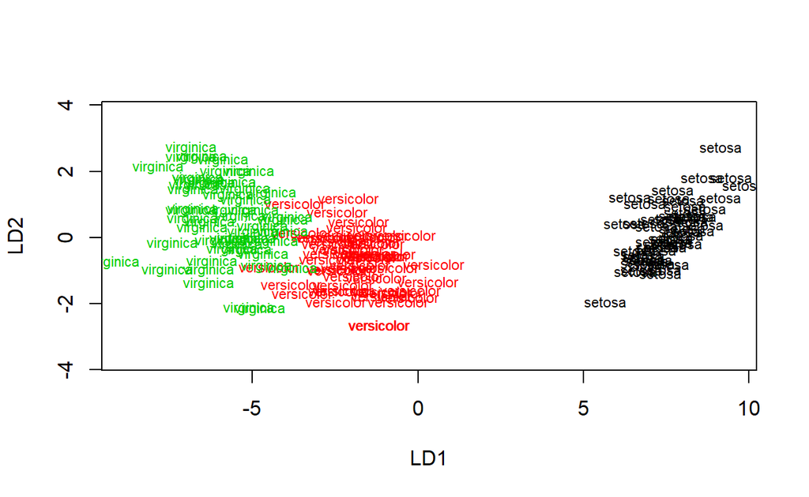

```
# 판별점수에 대한 산점도 11
plot(iris.lda,                                       # 함수 lda로부터 출력된 객체NA= as.integer(iris$Species))                 # 각 집단별로 동일한 색깔 지정
```

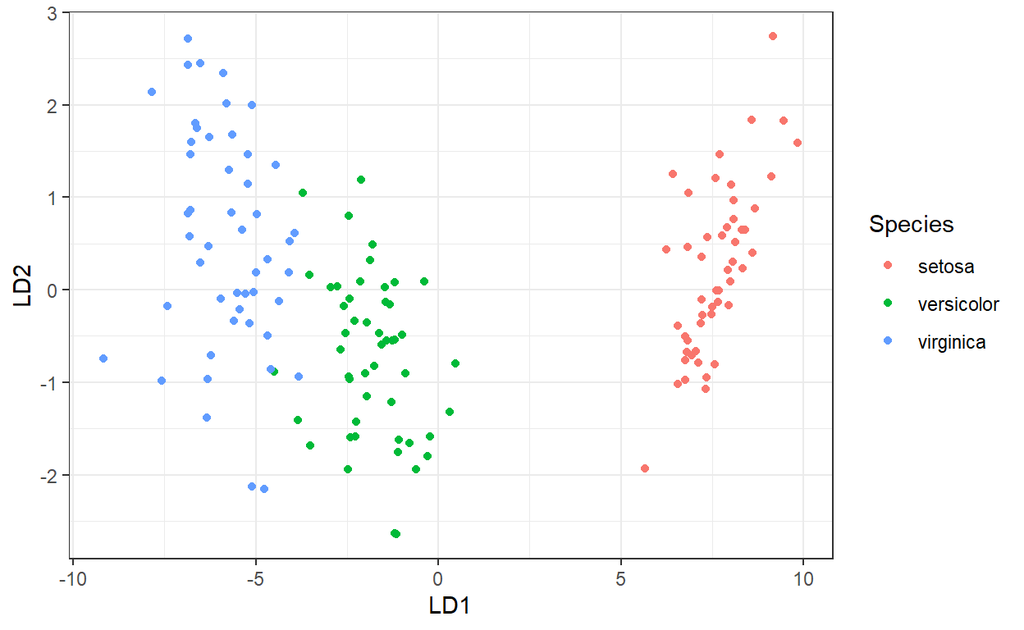

```
# 판별점수에 대한 산점도 22
pacman::p_load("ggplot2")

ggplot(iris.pred, aes(LD1, LD2)) +                   # 선형 판별점수, 예측 확률, 예측 집단 데이터 NAgeom_point(aes(color = Species)) +                 # 각 집단별로 동일한 색깔 지정  theme_bw()
```

`Caution!` 함수 `plot()`과 `ggplot()`을 이용해서 두 판별점수 (LD1, LD2)에 대한 산점도를 작성할 수 있다.  
`Result!` “Species”의 “setosa”는 첫 번째 판별함수에 의한 판별점수 `LD1`이 다른 두 종류와 달리 큰 양수값이다. 게다가, “setosa”는 다른 두 품종과 멀리 분리되어 있으나, “versicolor”와 “virginica”는 가깝게 인접해 있음을 볼 수 있다.

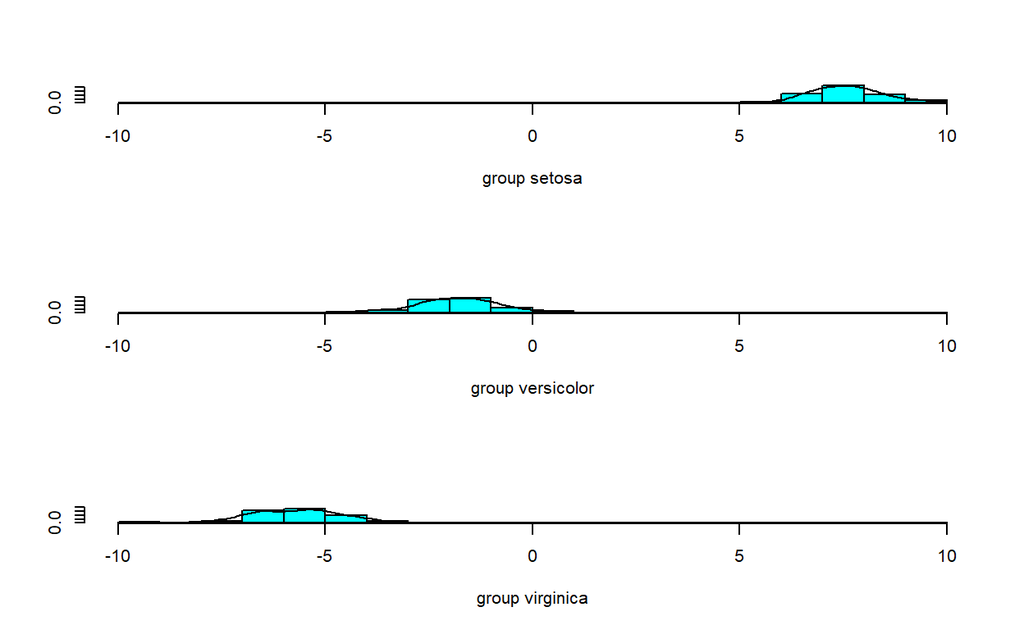

```
# 히스토그램
plot(iris.lda,                                       # 함수 lda로부터 출력된 객체NA= 1,                                      # 첫 번째 정준 판별점수만을 이용     type = "both")                                  # 히스토그램과 분포도 모두 출력
```

`Result!` 위의 산점도에서 확인한 것처럼 “Species”의 “setosa”는 첫 번째 판별함수에 의한 판별점수 `LD1`이 다른 두 종류와 달리 큰 양수값이며, 두 번째로 “versicolor”의 판별점수 값이 높으며, 마지막으로 “virginica”의 판별점수 값이 가장 낮다.

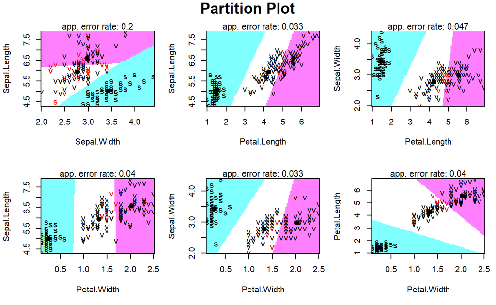

```
pacman::p_load("klaR")

partimat(Species ~ .,
         data = iris,
         method = "lda")
```

```
# 오분류표
pacman::p_load("DescTools")

# 도수분포표
iris.ctbl <- table(iris$Species,                     # 실제 집단                   pred$class)                       # 예측된 집단iris.ctbl
```

```
             setosa versicolor virginica
  setosa         50          0         0
  versicolor      0         48         2
  virginica       0          1        49
```

```
Desc(iris.ctbl,                                      # 도수분포표
     digits = 4)
```

```
--------------------------------------------------------------------
iris.ctbl (table)

Summary:
n: 2e+02, rows: 3e+00, columns: 3e+00

Pearson's Chi-squared test:
  X-squared = 282.59, df = 4, p-value < 2.2e-16
Likelihood Ratio:
  X-squared = 302.95, df = 4, p-value < 2.2e-16
Mantel-Haenszel Chi-squared:
  X-squared = 144.6, df = 1, p-value < 2.2e-16

Phi-Coefficient        1.373
Contingency Coeff.     0.808
Cramer's V             0.971


                      setosa   versicolor   virginica       Sum

setosa       freq      5e+01            0           0     5e+01
             perc   33.3333%      0.0000%     0.0000%  33.3333%
             p.row 100.0000%      0.0000%     0.0000%         .
             p.col 100.0000%      0.0000%     0.0000%         .

versicolor   freq          0        5e+01       2e+00     5e+01
             perc    0.0000%     32.0000%     1.3333%  33.3333%
             p.row   0.0000%     96.0000%     4.0000%         .
             p.col   0.0000%     97.9592%     3.9216%         .

virginica    freq          0        1e+00       5e+01     5e+01
             perc    0.0000%      0.6667%    32.6667%  33.3333%
             p.row   0.0000%      2.0000%    98.0000%         .
             p.col   0.0000%      2.0408%    96.0784%         .

Sum          freq      5e+01        5e+01       5e+01     2e+02
             perc   33.3333%     32.6667%    34.0000% 100.0000%
             p.row         .            .           .         .
             p.col         .            .           .         .
```

`Result!` 원래 집단 “setosa”에 속하는 50개의 개체 모두 집단 “setosa”에 제대로 분류되었다. 원래 집단 “versicolor”에 속하는 50개의 개체 중 48개(48/50=96%)는 제대로 분류되었으나 2개(2/50=4%)는 잘못 분류되었다. 또한, 원래 집단 “virginica”에 속하는 50개의 개체 중 49개(49/50=98)는 제대로 분류되었으나 1개(1/50=2)는 잘못 분류되었다. 유도된 선형 판별함수에 대한 오류율은 (2+1)/150=2%이며, 정확도는 (50+48+49)/150=98%이다.

# **4. 예측**

- 특별한 가정 하에서 판별함수 또는 확률밀도함수를 구하고 나면, 어떤 분류기준에 의해 새로운 개체들을 분류할 수 있다.
- R에서 유도된 판별함수에 의해 새로운 개체의 집단을 예측하기 위해서는 함수 `predict()`를 이용할 수 있다.
- 함수 `predict()`는 `사후확률이 가장 큰 집단`으로 새로운 개체를 분류한다.

```
# 데이터 불러오기
data(iris)
head(iris)
```

```
  Sepal.Length Sepal.Width Petal.Length Petal.Width Species
1          5.1         3.5          1.4         0.2  setosa
2          4.9         3.0          1.4         0.2  setosa
3          4.7         3.2          1.3         0.2  setosa
4          4.6         3.1          1.5         0.2  setosa
5          5.0         3.6          1.4         0.2  setosa
6          5.4         3.9          1.7         0.4  setosa
```

```
# 정준 판별분석
pacman::p_load("MASS")

iris.lda <- lda(Species ~ ., data = iris)

# 예측
predict(iris.lda,                            # 함수 lda로부터 출력된 객체NAiris)                                # 새로운 데이터
```

```
$class
  [1] setosa     setosa     setosa     setosa     setosa
  [6] setosa     setosa     setosa     setosa     setosa
 [11] setosa     setosa     setosa     setosa     setosa
 [16] setosa     setosa     setosa     setosa     setosa
 [21] setosa     setosa     setosa     setosa     setosa
 [26] setosa     setosa     setosa     setosa     setosa
 [31] setosa     setosa     setosa     setosa     setosa
 [36] setosa     setosa     setosa     setosa     setosa
 [41] setosa     setosa     setosa     setosa     setosa
 [46] setosa     setosa     setosa     setosa     setosa
 [51] versicolor versicolor versicolor versicolor versicolor
 [56] versicolor versicolor versicolor versicolor versicolor
 [61] versicolor versicolor versicolor versicolor versicolor
 [66] versicolor versicolor versicolor versicolor versicolor
```

[output cut: 323 more lines]

# **5. 오분류율 계산**

- 판별함수의 능력을 판단하기 위해 판별함수의 오분류율과 정확한 분류율을 이용할 수 있다.
- 오분류율을 계산하는 방법으로는 다음과 같다.
  1. 재대입에 의한 오분류율 계산
     - 판별함수를 유도하는 데 사용했던 데이터를 이용하여 오분류율을 계산한다.
  2. 표본분할에 의한 오분류율 계산
     - 데이터를 판별함수를 유도하는 데 사용하는 데이터와 오분류율을 계산하는 데이터 두 가지로 분할한다.
  3. 교차타당성에의한 오분류율 계산
     - 한 개만의 개체를 제외한 나머지 개체로 판별함수를 유도하고 제외한 한 개의 개체에 대해 오분류율을 계산하며, 모든 개체에 대해 이러한 과정을 적용한다.
- R에서 오분류율을 계산하기 적용할 수 있는 함수는 대표적으로 다음과 같다.
  1. 함수 `table()`
  2. Package `DescTools`에서 제공하는 함수 `Desc()`
  3. Package `caret`에서 제공하는 `confusionMatrix()`

```
# 데이터 불러오기
data(iris)
head(iris)
```

```
  Sepal.Length Sepal.Width Petal.Length Petal.Width Species
1          5.1         3.5          1.4         0.2  setosa
2          4.9         3.0          1.4         0.2  setosa
3          4.7         3.2          1.3         0.2  setosa
4          4.6         3.1          1.5         0.2  setosa
5          5.0         3.6          1.4         0.2  setosa
6          5.4         3.9          1.7         0.4  setosa
```

```
# 1. 재대입에 의한 오분류율 계산 NA## 정준 판별분석
pacman::p_load("MASS")

iris.lda <- lda(Species ~ ., data = iris)

## 예측
pred <- predict(iris.lda,                            # 함수 lda로부터 출력된 객체NAiris)                                # 판별함수를 유도하는 데 사용했던 데이터## 오분류율 계산
## 함수 table()iris.ctbl <- table(iris$Species,                     # 실제 집단                   pred$class)                       # 예측된 집단iris.ctbl
```

```
             setosa versicolor virginica
  setosa         50          0         0
  versicolor      0         48         2
  virginica       0          1        49
```

```
## 함수 Desc()pacman::p_load("DescTools")

Desc(iris.ctbl,                                      # 도수분포표
     digits = 4)
```

```
--------------------------------------------------------------------
iris.ctbl (table)

Summary:
n: 2e+02, rows: 3e+00, columns: 3e+00

Pearson's Chi-squared test:
  X-squared = 282.59, df = 4, p-value < 2.2e-16
Likelihood Ratio:
  X-squared = 302.95, df = 4, p-value < 2.2e-16
Mantel-Haenszel Chi-squared:
  X-squared = 144.6, df = 1, p-value < 2.2e-16

Phi-Coefficient        1.373
Contingency Coeff.     0.808
Cramer's V             0.971


                      setosa   versicolor   virginica       Sum

setosa       freq      5e+01            0           0     5e+01
             perc   33.3333%      0.0000%     0.0000%  33.3333%
             p.row 100.0000%      0.0000%     0.0000%         .
             p.col 100.0000%      0.0000%     0.0000%         .

versicolor   freq          0        5e+01       2e+00     5e+01
             perc    0.0000%     32.0000%     1.3333%  33.3333%
             p.row   0.0000%     96.0000%     4.0000%         .
             p.col   0.0000%     97.9592%     3.9216%         .

virginica    freq          0        1e+00       5e+01     5e+01
             perc    0.0000%      0.6667%    32.6667%  33.3333%
             p.row   0.0000%      2.0000%    98.0000%         .
             p.col   0.0000%      2.0408%    96.0784%         .

Sum          freq      5e+01        5e+01       5e+01     2e+02
             perc   33.3333%     32.6667%    34.0000% 100.0000%
             p.row         .            .           .         .
             p.col         .            .           .         .
```

```
## 함수 confusionMatrix()pacman::p_load("caret")

confusionMatrix(pred$class,                          # 예측된 집단                iris$Species)                        # 실제 집단
```

```
Confusion Matrix and Statistics

            Reference
Prediction   setosa versicolor virginica
  setosa         50          0         0
  versicolor      0         48         1
  virginica       0          2        49

Overall Statistics

               Accuracy : 0.98
                 95% CI : (0.9427, 0.9959)
    No Information Rate : 0.3333
    P-Value [Acc > NIR] : < 2.2e-16

                  Kappa : 0.97

 Mcnemar's Test P-Value : NA

Statistics by Class:

                     Class: setosa Class: versicolor Class: virginica
Sensitivity                 1.0000            0.9600           0.9800
Specificity                 1.0000            0.9900           0.9800
Pos Pred Value              1.0000            0.9796           0.9608
Neg Pred Value              1.0000            0.9802           0.9899
Prevalence                  0.3333            0.3333           0.3333
Detection Rate              0.3333            0.3200           0.3267
Detection Prevalence        0.3333            0.3267           0.3400
Balanced Accuracy           1.0000            0.9750           0.9800
```

```
# 2. 표본분할에 의한 오분류율 계산## 표본 분할
pacman::p_load("caret")

set.seed(200)                                        # Seed 고정
ind <- createDataPartition(iris$Species,             # 반응변수
                           p = .7,                   # 판별함수를 유도하는 데 사용되는 데이터 비율
                           list = F)                 # 출력 결과를 List로 반환할 것인지 여부  NAtrd <- iris[ind,]                                    # 판별함수를 유도하는 데 사용되는 데이터
ted <- iris[-ind,]                                   # 오분류율 계산을 위해 사용되는 데이터 NA
```

`Caution!` Package `caret`에서 제공하는 함수 `createDataPartition()`은 반응변수의 집단별 비율을 원본 데이터와 같게 유지하면서 판별함수를 유도하는 데 사용할 데이터의 인덱스를 추출한다.

```
## 정준 판별분석
pacman::p_load("MASS")

iris.lda <- lda(Species ~ ., data = trd)

## 예측
pred <- predict(iris.lda,                            # 함수 lda로부터 출력된 객체NAted)                                 # 새로운 데이터## 오분류율 계산
## 함수 table()iris.ctbl <- table(ted$Species,                      # 실제 집단                   pred$class)                       # 예측된 집단iris.ctbl
```

```
             setosa versicolor virginica
  setosa         15          0         0
  versicolor      0         15         0
  virginica       0          0        15
```

```
## 함수 Desc()pacman::p_load("DescTools")

Desc(iris.ctbl,                                      # 도수분포표
     digits = 4)
```

```
--------------------------------------------------------------------
iris.ctbl (table)

Summary:
n: 4e+01, rows: 3e+00, columns: 3e+00

Pearson's Chi-squared test:
  X-squared = 90, df = 4, p-value < 2.2e-16
Likelihood Ratio:
  X-squared = 98.875, df = 4, p-value < 2.2e-16
Mantel-Haenszel Chi-squared:
  X-squared = 44, df = 1, p-value = 3.284e-11

Phi-Coefficient        1.414
Contingency Coeff.     0.816
Cramer's V             1.000


                      setosa   versicolor   virginica       Sum

setosa       freq      2e+01            0           0     2e+01
             perc   33.3333%      0.0000%     0.0000%  33.3333%
             p.row 100.0000%      0.0000%     0.0000%         .
             p.col 100.0000%      0.0000%     0.0000%         .

versicolor   freq          0        2e+01           0     2e+01
             perc    0.0000%     33.3333%     0.0000%  33.3333%
             p.row   0.0000%    100.0000%     0.0000%         .
             p.col   0.0000%    100.0000%     0.0000%         .

virginica    freq          0            0       2e+01     2e+01
             perc    0.0000%      0.0000%    33.3333%  33.3333%
             p.row   0.0000%      0.0000%   100.0000%         .
             p.col   0.0000%      0.0000%   100.0000%         .

Sum          freq      2e+01        2e+01       2e+01     4e+01
             perc   33.3333%     33.3333%    33.3333% 100.0000%
             p.row         .            .           .         .
             p.col         .            .           .         .
```

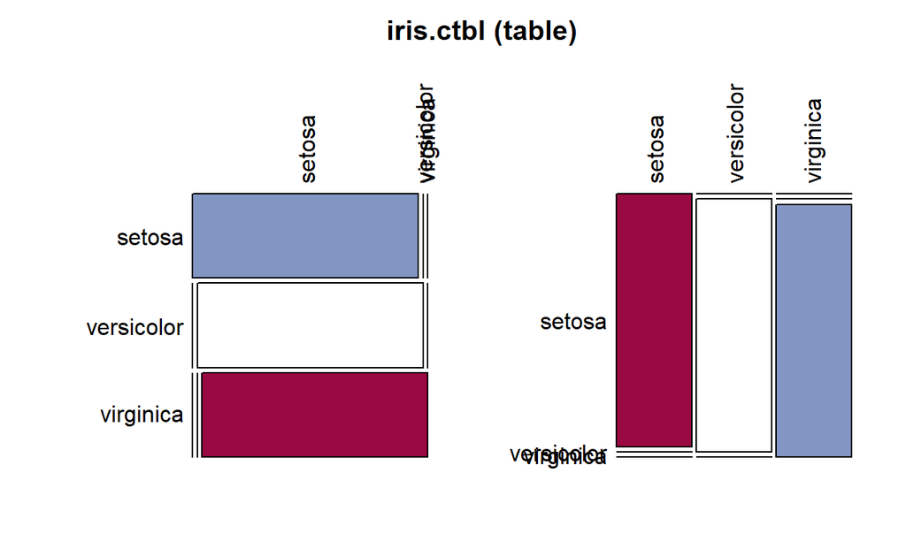

```
## 함수 confusionMatrix()pacman::p_load("caret")

confusionMatrix(pred$class,                          # 예측된 집단                ted$Species)                         # 실제 집단
```

```
Confusion Matrix and Statistics

            Reference
Prediction   setosa versicolor virginica
  setosa         15          0         0
  versicolor      0         15         0
  virginica       0          0        15

Overall Statistics

               Accuracy : 1
                 95% CI : (0.9213, 1)
    No Information Rate : 0.3333
    P-Value [Acc > NIR] : < 2.2e-16

                  Kappa : 1

 Mcnemar's Test P-Value : NA

Statistics by Class:

                     Class: setosa Class: versicolor Class: virginica
Sensitivity                 1.0000            1.0000           1.0000
Specificity                 1.0000            1.0000           1.0000
Pos Pred Value              1.0000            1.0000           1.0000
Neg Pred Value              1.0000            1.0000           1.0000
Prevalence                  0.3333            0.3333           0.3333
Detection Rate              0.3333            0.3333           0.3333
Detection Prevalence        0.3333            0.3333           0.3333
Balanced Accuracy           1.0000            1.0000           1.0000
```

```
# 3. 교차타당성에 의한 오분류율 계산
## 정준 판별분석
pacman::p_load("MASS")

iris.lda <- lda(Species ~ ., data = iris,
                CV = TRUE)
```

`Caution!` 함수 `lda()`의 옵션 `CV = TRUE`을 지정하면 교차타당성에 의한 오분류율을 계산할 수 있다.

```
## 오분류율 계산
## 함수 table()iris.ctbl <- table(iris$Species,                      # 실제 집단                   iris.lda$class)                    # 예측된 집단iris.ctbl
```

```
             setosa versicolor virginica
  setosa         50          0         0
  versicolor      0         48         2
  virginica       0          1        49
```

```
## 함수 Desc()pacman::p_load("DescTools")

Desc(iris.ctbl,                                      # 도수분포표
     digits = 4)
```

```
--------------------------------------------------------------------
iris.ctbl (table)

Summary:
n: 2e+02, rows: 3e+00, columns: 3e+00

Pearson's Chi-squared test:
  X-squared = 282.59, df = 4, p-value < 2.2e-16
Likelihood Ratio:
  X-squared = 302.95, df = 4, p-value < 2.2e-16
Mantel-Haenszel Chi-squared:
  X-squared = 144.6, df = 1, p-value < 2.2e-16

Phi-Coefficient        1.373
Contingency Coeff.     0.808
Cramer's V             0.971


                      setosa   versicolor   virginica       Sum

setosa       freq      5e+01            0           0     5e+01
             perc   33.3333%      0.0000%     0.0000%  33.3333%
             p.row 100.0000%      0.0000%     0.0000%         .
             p.col 100.0000%      0.0000%     0.0000%         .

versicolor   freq          0        5e+01       2e+00     5e+01
             perc    0.0000%     32.0000%     1.3333%  33.3333%
             p.row   0.0000%     96.0000%     4.0000%         .
             p.col   0.0000%     97.9592%     3.9216%         .

virginica    freq          0        1e+00       5e+01     5e+01
             perc    0.0000%      0.6667%    32.6667%  33.3333%
             p.row   0.0000%      2.0000%    98.0000%         .
             p.col   0.0000%      2.0408%    96.0784%         .

Sum          freq      5e+01        5e+01       5e+01     2e+02
             perc   33.3333%     32.6667%    34.0000% 100.0000%
             p.row         .            .           .         .
             p.col         .            .           .         .
```

```
## 함수 confusionMatrix()pacman::p_load("caret")

confusionMatrix(iris.lda$class,                       # 예측된 집단                iris$Species)                         # 실제 집단
```

```
Confusion Matrix and Statistics

            Reference
Prediction   setosa versicolor virginica
  setosa         50          0         0
  versicolor      0         48         1
  virginica       0          2        49

Overall Statistics

               Accuracy : 0.98
                 95% CI : (0.9427, 0.9959)
    No Information Rate : 0.3333
    P-Value [Acc > NIR] : < 2.2e-16

                  Kappa : 0.97

 Mcnemar's Test P-Value : NA

Statistics by Class:

                     Class: setosa Class: versicolor Class: virginica
Sensitivity                 1.0000            0.9600           0.9800
Specificity                 1.0000            0.9900           0.9800
Pos Pred Value              1.0000            0.9796           0.9608
Neg Pred Value              1.0000            0.9802           0.9899
Prevalence                  0.3333            0.3333           0.3333
Detection Rate              0.3333            0.3200           0.3267
Detection Prevalence        0.3333            0.3267           0.3400
Balanced Accuracy           1.0000            0.9750           0.9800
```